# PS3 Zongyang Li

# Problem 2.2

#### Comment:

```r
weo.probit_4 <- glm(gen_str_bal_2 ~ gdp_growth + gen_lend_borrow_net + gen_gov_rev + gns, family = binomial(link = "probit"), data = weo_3)
summary(weo.probit_4)
```

```
##
## Call:
## glm(formula = gen_str_bal_2 ~ gdp_growth + gen_lend_borrow_net +
##     gen_gov_rev + gns, family = binomial(link = "probit"), data = weo_3)
##
## Deviance Residuals:
##     Min       1Q   Median       3Q      Max
## -1.6549  -0.4062  -0.2524  -0.1391   2.3225
##
## Coefficients:
##                     Estimate Std. Error z value Pr(>|z|)
## (Intercept)          0.16453    2.60824   0.063   0.9497
## gdp_growth          -0.35807    0.28349  -1.263   0.2066
## gen_lend_borrow_net  0.21154    0.17363   1.218   0.2231
## gen_gov_rev         -0.06246    0.03728  -1.675   0.0939 .
## gns                  0.08630    0.06717   1.285   0.1989
## ---
## Signif. codes:  0 '***' 0.001 '**' 0.01 '*' 0.05 '.' 0.1 ' ' 1
##
## (Dispersion parameter for binomial family taken to be 1)
##
##     Null deviance: 30.405  on 40  degrees of freedom
## Residual deviance: 20.652  on 36  degrees of freedom
## AIC: 30.652
##
## Number of Fisher Scoring iterations: 7
```

and then we can see that the AIC is 30 now,lower than before which is 32. So the model is performing better.

# Problem 2.3 - 2.4

```r
# install.packages("mfx")
library(mfx)
weo.probitmfx <- probitmfx(formula = gen_str_bal_2 ~ export_vol_change + gdp_growth + gen_lend_borrow_net + gen_gov_rev + gns, atmean=FALSE, data = weo_3)
weo.probitmfx
```

```
## Call:
## probitmfx(formula = gen_str_bal_2 ~ export_vol_change + gdp_growth +
##     gen_lend_borrow_net + gen_gov_rev + gns, data = weo_3, atmean = FALSE)
##
## Marginal Effects:
##                          dF/dx  Std. Err.       z  P>|z|
## export_vol_change   -0.0092586  0.0162665 -0.5692 0.5692
## gdp_growth          -0.0355904  0.0432227 -0.8234 0.4103
## gen_lend_borrow_net  0.0230509  0.0237571  0.9703 0.3319
## gen_gov_rev         -0.0078131  0.0048484 -1.6115 0.1071
## gns                  0.0124704  0.0093247  1.3374 0.1811
```

#### Comment:

From the regression output of probitmfx, we may observe that the marginal effects of gdp growth on the probability of deterioration of government budget is -0.0355904. Note we have specified that atmean=FALSE, this is saying that the we calculates the average partial effects.

The standard error is given by: 0.0432227 as in the output of the regression.

# Problem 2.5

```r
weo_4 <- weo_3 %>% mutate(euro = ifelse(country =="Czech Republic"|country =="Iceland",1,ifelse(is.na(output_gap),0,ifelse(country == "Korea" | country == "Japan" | country == "Australia"|country == "Canada",0,1))))

weo.probitmfx_2 <- probitmfx(formula = gen_str_bal_2 ~ export_vol_change + gdp_growth + gen_lend_borrow_net + gen_gov_rev + gns + euro, atmean=FALSE, data = weo_4)
weo.probitmfx_2
```

```
## Call:
## probitmfx(formula = gen_str_bal_2 ~ export_vol_change + gdp_growth +
##     gen_lend_borrow_net + gen_gov_rev + gns + euro, data = weo_4,
##     atmean = FALSE)
##
## Marginal Effects:
##                          dF/dx  Std. Err.       z  P>|z|
## export_vol_change   -0.0107612  0.0157511 -0.6832 0.4945
## gdp_growth          -0.0465673  0.0461378 -1.0093 0.3128
## gen_lend_borrow_net  0.0238669  0.0238557  1.0005 0.3171
## gen_gov_rev         -0.0116687  0.0084778 -1.3764 0.1687
## gns                  0.0118530  0.0091470  1.2958 0.1950
## euro                 0.0899108  0.1476594  0.6089 0.5426
##
## dF/dx is for discrete change for the following variables:
##
## [1] "euro"
```

#### Comment:

From the regression output, we can see that the marginal effects of being a EU country on the probability of deterioration of government budget is 0.0899108. And this also the average partial effects.

# Problem 3

### Import Data

```r
crime <- read.table("crime.txt")

crime_1 <- crime %>%
  dplyr::mutate(district = V1, year = V2, crime = V3, clrprc1 = V4, clrprc2 = V5, d78 = V6, avgclr = V7, lcrime = V8, clcrime = V9, cavgclr = V10, cclrprc1 = V11, cclrprc2 = V12) %>%
  dplyr::select(district,year,crime,clrprc1,clrprc2,d78,avgclr,lcrime,clcrime,cavgclr,cclrprc1,cclrprc2) %>%
  dplyr::mutate(crime_mean = mean(crime, na.rm = T), crime_compare = ifelse(crime > crime_mean, 1, 0))

train = subset(crime_1, d78<1)
test = subset(crime_1, d78>0)
```

# Problem 3.1 - LDA

```r
library(MASS)
crime.lda <- lda(crime_compare ~ clrprc1+clrprc2, data=train, na.action="na.omit")
pr.lda <- predict(crime.lda,newdata = test)
```

### Show result as a table

```r
table(train$crime_compare, pr.lda$class, dnn = c('Actual','Predicted LDA'))
```

```
##       Predicted LDA
## Actual  0  1
##      0 27 11
##      1  3 12
```

# Problem 3.2 - QDA

```r
crime.qda <- qda(crime_compare ~ clrprc1+clrprc2, data=train, na.action="na.omit")
```

### Compare - Method 1: the build in cross-validation function in LDA and QDA

```r
crime.lda_cv <- lda(crime_compare ~ clrprc1+clrprc2, data=train, na.action="na.omit",CV = TRUE)
crime.qda_cv <- qda(crime_compare ~ clrprc1+clrprc2, data=train, na.action="na.omit",CV = TRUE)
    # cmt: CV=TRUE generates leave-one-out cross validation.
table(train$crime_compare, crime.lda_cv$class, dnn = c('Actual Group','Predicted LDA'))
```

```
##             Predicted LDA
## Actual Group  0  1
##            0 32  6
##            1  7  8
```

```r
table(train$crime_compare, crime.qda_cv$class, dnn = c('Actual Group','Predicted QDA'))
```

```
##             Predicted QDA
## Actual Group  0  1
##            0 33  5
##            1  5 10
```

### Comment:

from the ouput table we can see very obviously that QDA did a better job at predicting since there are more groups predicted right by QDA.

### Compare - Method 2: manul cross validation and compare MSE

- predict on test dataset

```r
    pr.qda <- predict(crime.qda,newdata = test)
    # turn result to integer
    pr.lda_class <- as.integer(as.character(pr.lda$class))
    pr.qda_class <- as.integer(as.character(pr.qda$class))
```

- caculate MSE

```r
MSE.lda <- sum((test$crime_compare - pr.lda_class)^2)/nrow(test)
MSE.qda <- sum((test$crime_compare - pr.qda_class)^2)/nrow(test)

print(paste(MSE.lda,MSE.qda))
```

```
## [1] "0.245283018867925 0.188679245283019"
```

### Comment:

From the result of MSE: 0.25 for LDA and 0.19 for QDA we may conclude that QDA performs better

# Problem 3.3 - kNN

```r
set.seed(100)
library(class)
```

# build train and test datasets

```r
knntrain <- train[,c(4:5,14)]
knntest <- test[,c(4:5,14)]
```

# fit model, predict and see MSE

```r
pr.knn <- knn(knntrain,knntest,knntrain$crime_compare, k = 1)
table(pr.knn,knntest$crime_compare)
```

```
##
## pr.knn  0  1
##      0 20  9
##      1  9 15
```

```r
pr.knn_class <- as.integer(pr.knn)
MSE.knn_0 <- sum((knntest$crime_compare - pr.knn_class)^2)/nrow(knntest)
MSE.knn_0
```

```
## [1] 1.339623
```

# try to find the minimum MSE

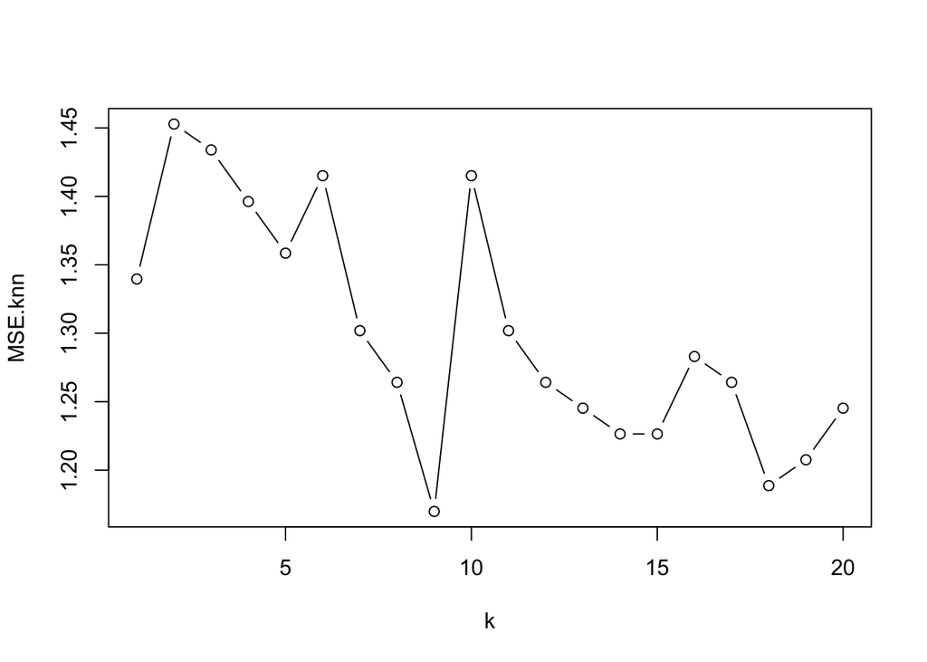

```r
MSE.knn <- rep(0, 20)
k <- 1:20
for(x in k){
    pr.knn <- knn(knntrain,knntest,knntrain$crime_compare, k = x)
    pr.knn_class <- as.integer(pr.knn)
    MSE.knn[x] <- sum((knntest$crime_compare - pr.knn_class)^2)/nrow(knntest)
}
plot(k, MSE.knn, type = 'b')
```

### Comment: From the plotted graph we can see that the MSE is minimized at k=9, so we choose k=9 in this case

```r
pr.knn <- knn(knntrain,knntest,knntrain$crime_compare, k = 9)
table(pr.knn,knntest$crime_compare)
```

```
##
## pr.knn  0  1
##      0 24  5
##      1  5 19
```

```r
pr.knn_class <- as.integer(pr.knn)
MSE.knn <- sum((knntest$crime_compare - pr.knn_class)^2)/nrow(knntest)
MSE.knn
```

```
## [1] 1.188679
```

```r
print(paste(MSE.lda,MSE.qda,MSE.knn))
```

```
## [1] "0.245283018867925 0.188679245283019 1.18867924528302"
```